[figure not shown]

# MBD-PT 2023 Social Network Analysis

## Prescription Generation and Typical Interactions by Community.

[figure not shown]

# **Table of contents**

- 0. Description & General Objective
- 1. Import Libraries
- 2. Import Datasets
- 3. Preparation of ATC classifications
- 4. Graph Creation
  - 4.1 Edges
  - 4.2 Nodes
  - 4.3 Graph
- 5. Analysis
  - 5.1 Connected graphs
  - 5.2 Centrality metrics
  - 5.3 Neighbors Statistics
  - 5.4 Interaction Matrix (Vertex to each of neighbors)
- 6. Real Case: Insulin, Atorvastatin , Valsarten
  - a) Checking if prefered prescriptions have any interaction
  - b) Checking all interations that should be avoided to treat these 3 conditions
  - c) Proposing one drug for each conditions with no interactions
  - d) Focusing on combinations which include Insulin glulisine and Atorvastatin
  - e) Final check that our final selection of drugs do not have any interactions
- 7. Drug Communities based on interactions
  - 7.1) Creation of the communities
  - 7.2) Neighbor Analysis on ATC1
  - 7.3) Antineoplastics:
  - 7.4) Alimentary Tract (A) /Cardiovascular (C) /Antiinfective (J) /Nervious(N)
  - 7.5) Alimentary Tract (A)
  - 7.6) Antineoplastics (L)
  - 7.7) Nervious System(N)
  - 7.8) Blood

# **0.Descriptive and General Objective**

**Goal 1**: Building the graph of drug interactions and be able to support the prescription process by allowing to easily find the right drugs for the conditions treated while avoiding any bad interactions.

**Goal 2**: Find different communities of interactions in order to find patterns on what conditions the drugs tend to interact more and therefore minimize the risk of interactions.

# **1. Import Libraries**

```python
!pip install pycairo
```

```python
# !pip install igraph
from igraph import *
import pandas as pd
import cairo
import matplotlib.pyplot as plt
import numpy as np
import difflib
import itertools
```

# **2. Import Datasets**

# **2.1 Drug Interactions**

Loading Drugs Interactions from DDInter Database. They will be the base for the edges and nodes of our graph.

```python
df_A=pd.read_csv('ddinter_downloads_code_A.csv',sep=',')
df_A['ATC']='A'
df_B=pd.read_csv('ddinter_downloads_code_B.csv',sep=',')
df_B['ATC']='B'
df_D=pd.read_csv('ddinter_downloads_code_D.csv',sep=',')
df_D['ATC']='D'
df_H=pd.read_csv('ddinter_downloads_code_H.csv',sep=',')
df_H['ATC']='H'
df_L=pd.read_csv('ddinter_downloads_code_L.csv',sep=',')
df_L['ATC']='L'
df_P=pd.read_csv('ddinter_downloads_code_P.csv',sep=',')
df_P['ATC']='P'
df_R=pd.read_csv('ddinter_downloads_code_R.csv',sep=',')
df_R['ATC']='R'
df_V=pd.read_csv('ddinter_downloads_code_V.csv',sep=',')
df_V['ATC']='V'
df_main=pd.concat([df_A,df_B,df_D,df_H,df_L,df_P,df_R,df_V])
df_main
```

|  | DDInterID_A | Drug_A | DDInterID_B | Drug_B | Level | ATC |
| --- | --- | --- | --- | --- | --- | --- |
| 0 | DDInter1263 | Naltrexone | DDInter1 | Abacavir | Moderate | A |
| 1 | DDInter1 | Abacavir | DDInter1348 | Orlistat | Moderate | A |
| 2 | DDInter58 | Aluminum hydroxide | DDInter582 | Dolutegravir | Major | A |
| 3 | DDInter112 | Aprepitant | DDInter582 | Dolutegravir | Minor | A |
| 4 | DDInter138 | Attapulgite | DDInter582 | Dolutegravir | Major | A |
| ... | ... | ... | ... | ... | ... | ... |
| 12019 | DDInter513 | Dexamethasone | DDInter801 | Galactose | Unknown | V |
| 12020 | DDInter1683 | Sodium bicarbonate | DDInter801 | Galactose | Unknown | V |
| 12021 | DDInter317 | Cefepime | DDInter801 | Galactose | Unknown | V |
| 12022 | DDInter1906 | Ursodeoxycholic acid | DDInter801 | Galactose | Unknown | V |
| 12023 | DDInter1663 | Sevelamer | DDInter766 | Fluticasone | Unknown | V |

222383 rows × 6 columns

# **3. Preparation of the Anatomical Therapeutic Chemical (ATC) classifications**

This classification will alow us to enrich the dataset and link each drugs with the conditions that they treat. The same drug can treat several conditions. For prescriptions we will use the **level 3 (Chemical, Pharmacological or Therapeutic subgroup)** and for overall patterns on communities **level 1 (main anatomical or pharmacological groups)**

https://www.who.int/tools/atc-ddd-toolkit/atc-classification

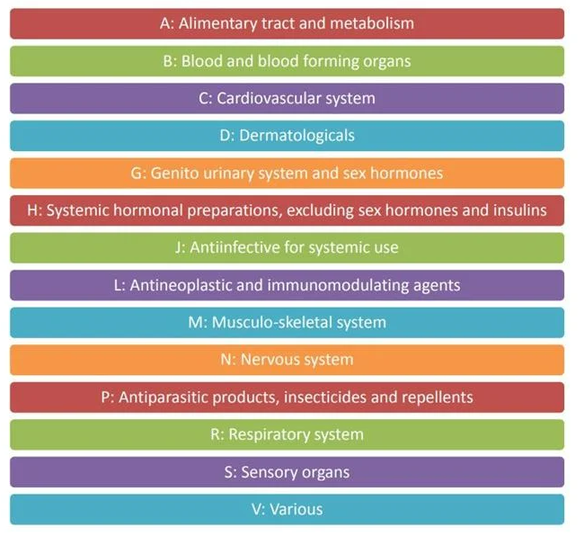

```python
df_ATC=pd.read_excel('ATC Classifications and Names.xlsx')
df_ATC=df_ATC[['atc_name','atc_code']]
df_ATC['atc_name']=df_ATC['atc_name'].str.capitalize()
df_ATC['atc_code3']=df_ATC['atc_code'].str[:5]
df_ATC['atc_code2']=df_ATC['atc_code'].str[:3]
df_ATC['atc_code1']=df_ATC['atc_code'].str[:1]
df_ATC=df_ATC.drop_duplicates(subset=['atc_name','atc_code'])

df_ATC_codes=df_ATC.groupby('atc_name')['atc_code'].agg(lambda x: list(x))
df_ATC_codes = df_ATC_codes.reset_index()
df_ATC_codes=df_ATC_codes.rename(columns={'atc_code': 'atc_codes'})

df_ATC_codes2=df_ATC.groupby('atc_name')['atc_code2'].agg(lambda x: list(x))
df_ATC_codes2 = df_ATC_codes2.reset_index()
df_ATC_codes2=df_ATC_codes2.rename(columns={'atc_code': 'atc_codes'})

df_ATC_codes3=df_ATC.groupby('atc_name')['atc_code1'].agg(lambda x: list(x))
df_ATC_codes3 = df_ATC_codes3.reset_index()
df_ATC_codes3=df_ATC_codes3.rename(columns={'atc_code': 'atc_codes'})

df_ATC_codes4=df_ATC.groupby('atc_name')['atc_code3'].agg(lambda x: list(x))
df_ATC_codes4 = df_ATC_codes4.reset_index()
df_ATC_codes4=df_ATC_codes4.rename(columns={'atc_code': 'atc_codes'})

df_ATC=df_ATC_codes.merge(df_ATC_codes2,on='atc_name')
df_ATC=df_ATC.merge(df_ATC_codes3,on='atc_name')
df_ATC=df_ATC.merge(df_ATC_codes4,on='atc_name')

df_ATC_exp=df_ATC.explode('atc_code1')

df_ATC_exp = pd.pivot_table(df_ATC_exp, index='atc_name', columns='atc_code1', aggfunc='size', fill_value=0)

df_ATC_exp = df_ATC_exp.reset_index()


df_ATC=df_ATC.merge(df_ATC_exp,on='atc_name')

df_ATC
```

|  | atc_name | atc_codes | atc_code2 | atc_code1 | atc_code3 | A | B | C | D | G | H | J | L | M | N | P | R | S | V |
| --- | --- | --- | --- | --- | --- | --- | --- | --- | --- | --- | --- | --- | --- | --- | --- | --- | --- | --- | --- |
| 0 | (2-benzhydryloxyethyl)diethyl-methylammonium i... | [A03AB16] | [A03] | [A] | [A03AB] | 1 | 0 | 0 | 0 | 0 | 0 | 0 | 0 | 0 | 0 | 0 | 0 | 0 | 0 |
| 1 | 13c-urea | [V04CX05] | [V04] | [V] | [V04CX] | 0 | 0 | 0 | 0 | 0 | 0 | 0 | 0 | 0 | 0 | 0 | 0 | 0 | 1 |
| 2 | 2-(4-chlorphenoxy)-ethanol | [D01AE06] | [D01] | [D] | [D01AE] | 0 | 0 | 0 | 1 | 0 | 0 | 0 | 0 | 0 | 0 | 0 | 0 | 0 | 0 |
| 3 | 2-amino-1-phenylethanol derivatives | [C04AA] | [C04] | [C] | [C04AA] | 0 | 0 | 1 | 0 | 0 | 0 | 0 | 0 | 0 | 0 | 0 | 0 | 0 | 0 |
| 4 | 3-oxoandrosten (4) derivatives | [G03BA] | [G03] | [G] | [G03BA] | 0 | 0 | 0 | 0 | 1 | 0 | 0 | 0 | 0 | 0 | 0 | 0 | 0 | 0 |
| ... | ... | ... | ... | ... | ... | ... | ... | ... | ... | ... | ... | ... | ... | ... | ... | ... | ... | ... | ... |
| 5547 | Zoster, live attenuated | [J07BK02] | [J07] | [J] | [J07BK] | 0 | 0 | 0 | 0 | 0 | 0 | 1 | 0 | 0 | 0 | 0 | 0 | 0 | 0 |
| 5548 | Zoster, purified antigen | [J07BK03] | [J07] | [J] | [J07BK] | 0 | 0 | 0 | 0 | 0 | 0 | 1 | 0 | 0 | 0 | 0 | 0 | 0 | 0 |
| 5549 | Zotepine | [N05AX11] | [N05] | [N] | [N05AX] | 0 | 0 | 0 | 0 | 0 | 0 | 0 | 0 | 0 | 1 | 0 | 0 | 0 | 0 |
| 5550 | Zucapsaicin | [M02AB02] | [M02] | [M] | [M02AB] | 0 | 0 | 0 | 0 | 0 | 0 | 0 | 0 | 1 | 0 | 0 | 0 | 0 | 0 |
| 5551 | Zuclopenthixol | [N05AF05] | [N05] | [N] | [N05AF] | 0 | 0 | 0 | 0 | 0 | 0 | 0 | 0 | 0 | 1 | 0 | 0 | 0 | 0 |

5552 rows × 19 columns

# **4. Graph Creation**

# **4.1 Edges**

**Edges** will be the interactions amongs each pair of drugs. **There are 4 levels. Minor, Moderate , Major and Unknown. They will be coded as 1,2,3 and 2 respectively**. The reason is that the higher the number the higher the interaction. Unknown was decided to leave it as 2 since this is the average.

```python
df_edges=df_main[['DDInterID_A','DDInterID_B','Level','ATC']]
df_edges.drop_duplicates(subset=['DDInterID_A','DDInterID_B'],inplace=True)
level_inst_func = lambda x: 3 if x == 'Major' else 2 if x == 'Moderate' else 1 if x == 'Minor' else 2
df_edges['Level_inst'] = df_edges['Level'].apply(level_inst_func)
df_edges
```

[output not shown]

|  | DDInterID_A | DDInterID_B | Level | ATC | Level_inst |
| --- | --- | --- | --- | --- | --- |
| 0 | DDInter1263 | DDInter1 | Moderate | A | 2 |
| 1 | DDInter1 | DDInter1348 | Moderate | A | 2 |
| 2 | DDInter58 | DDInter582 | Major | A | 3 |
| 3 | DDInter112 | DDInter582 | Minor | A | 1 |
| 4 | DDInter138 | DDInter582 | Major | A | 3 |
| ... | ... | ... | ... | ... | ... |
| 12011 | DDInter305 | DDInter801 | Unknown | V | 2 |
| 12013 | DDInter1325 | DDInter801 | Unknown | V | 2 |
| 12015 | DDInter334 | DDInter801 | Unknown | V | 2 |
| 12016 | DDInter1553 | DDInter801 | Unknown | V | 2 |
| 12021 | DDInter317 | DDInter801 | Unknown | V | 2 |

160235 rows × 5 columns

# **4.2 Nodes**

**Nodes** are each of the drugs. Here we enrich them with the ATC levels as their attributes.

```python
df_nodesA=df_main[['DDInterID_A','Drug_A']]
df_nodesB=df_main[['DDInterID_B','Drug_B']]
df_nodesB.rename(columns={'DDInterID_B': 'DDInterID_A', 'Drug_B': 'Drug_A'}, inplace=True)
df_nodes=pd.concat([df_nodesA,df_nodesB],ignore_index=True).drop_duplicates(subset='DDInterID_A').reindex()
```

[output not shown]

```python
df_nodes['Drug'] = df_nodes['Drug_A']
df_nodes['Drug'] = df_nodes['Drug'].apply(lambda x:(difflib.get_close_matches(x, df_ATC['atc_name'])[:1] or [None])[0])
df_nodes2=df_nodes.merge(df_ATC,how='left',left_on='Drug',right_on='atc_name' )
```

# **4.3 Creation of the graph**

```python
g1 = Graph.DataFrame(df_edges, directed=False,use_vids=False,vertices=df_nodes2)
```

```python
g1.get_vertex_dataframe()
```

| vertex ID | name | Drug_A | Drug | atc_name | atc_codes | atc_code2 | atc_code1 | atc_code3 | A | B | ... | G | H | J | L | M | N | P | R | S | V |
| --- | --- | --- | --- | --- | --- | --- | --- | --- | --- | --- | --- | --- | --- | --- | --- | --- | --- | --- | --- | --- | --- |
| 0 | DDInter1263 | Naltrexone | Naltrexone | Naltrexone | [N07BB04] | [N07] | [N] | [N07BB] | 0.0 | 0.0 | ... | 0.0 | 0.0 | 0.0 | 0.0 | 0.0 | 1.0 | 0.0 | 0.0 | 0.0 | 0.0 |
| 1 | DDInter1 | Abacavir | Abacavir | Abacavir | [J05AF06] | [J05] | [J] | [J05AF] | 0.0 | 0.0 | ... | 0.0 | 0.0 | 1.0 | 0.0 | 0.0 | 0.0 | 0.0 | 0.0 | 0.0 | 0.0 |
| 2 | DDInter58 | Aluminum hydroxide | Aluminium hydroxide | Aluminium hydroxide | [A02AB01] | [A02] | [A] | [A02AB] | 1.0 | 0.0 | ... | 0.0 | 0.0 | 0.0 | 0.0 | 0.0 | 0.0 | 0.0 | 0.0 | 0.0 | 0.0 |
| 3 | DDInter112 | Aprepitant | Aprepitant | Aprepitant | [A04AD12] | [A04] | [A] | [A04AD] | 1.0 | 0.0 | ... | 0.0 | 0.0 | 0.0 | 0.0 | 0.0 | 0.0 | 0.0 | 0.0 | 0.0 | 0.0 |
| 4 | DDInter138 | Attapulgite | Attapulgite | Attapulgite | [A07BC04] | [A07] | [A] | [A07BC] | 1.0 | 0.0 | ... | 0.0 | 0.0 | 0.0 | 0.0 | 0.0 | 0.0 | 0.0 | 0.0 | 0.0 | 0.0 |
| ... | ... | ... | ... | ... | ... | ... | ... | ... | ... | ... | ... | ... | ... | ... | ... | ... | ... | ... | ... | ... | ... |
| 1934 | DDInter1219 | Milk thistle | Miglitol | Miglitol | [A10BF02] | [A10] | [A] | [A10BF] | 1.0 | 0.0 | ... | 0.0 | 0.0 | 0.0 | 0.0 | 0.0 | 0.0 | 0.0 | 0.0 | 0.0 | 0.0 |
| 1935 | DDInter728 | Ferumoxides | Peroxides | Peroxides | [D10AE] | [D10] | [D] | [D10AE] | 0.0 | 0.0 | ... | 0.0 | 0.0 | 0.0 | 0.0 | 0.0 | 0.0 | 0.0 | 0.0 | 0.0 | 0.0 |
| 1936 | DDInter1786 | Tetrofosmin | Terazosin | Terazosin | [G04CA03] | [G04] | [G] | [G04CA] | 0.0 | 0.0 | ... | 1.0 | 0.0 | 0.0 | 0.0 | 0.0 | 0.0 | 0.0 | 0.0 | 0.0 | 0.0 |
| 1937 | DDInter1689 | Sodium iodide | Sodium iodide (131i) | Sodium iodide (131i) | [V09FX03, V10XA01] | [V09, V10] | [V, V] | [V09FX, V10XA] | 0.0 | 0.0 | ... | 0.0 | 0.0 | 0.0 | 0.0 | 0.0 | 0.0 | 0.0 | 0.0 | 0.0 | 2.0 |
| 1938 | DDInter1310 | Norelgestromin | Nomegestrol | Nomegestrol | [G03DB04] | [G03] | [G] | [G03DB] | 0.0 | 0.0 | ... | 1.0 | 0.0 | 0.0 | 0.0 | 0.0 | 0.0 | 0.0 | 0.0 | 0.0 | 0.0 |

1939 rows × 22 columns

```python
g1.get_edge_dataframe()
```

| edge ID | source | target | Level | ATC | Level_inst |
| --- | --- | --- | --- | --- | --- |
| 0 | 0 | 1 | Moderate | A | 2 |
| 1 | 1 | 548 | Moderate | A | 2 |
| 2 | 2 | 7 | Major | A | 3 |
| 3 | 3 | 7 | Minor | A | 1 |
| 4 | 4 | 7 | Major | A | 3 |
| ... | ... | ... | ... | ... | ... |
| 160230 | 715 | 1870 | Unknown | V | 2 |
| 160231 | 546 | 1870 | Unknown | V | 2 |
| 160232 | 1042 | 1870 | Unknown | V | 2 |
| 160233 | 557 | 1870 | Unknown | V | 2 |
| 160234 | 1092 | 1870 | Unknown | V | 2 |

160235 rows × 5 columns

```python
g1.summary()
```

```
'IGRAPH UN-- 1939 160235 -- \n+ attr: A (v), B (v), C (v), D (v), Drug (v), Drug_A (v), G (v), H (v), J (v), L (v), M (v), N (v), P (v), R (v), S (v), V (v), atc_code1 (v), atc_code2 (v), atc_code3 (v), atc_codes (v), atc_name (v), name (v), ATC (e), Level (e), Level_inst (e)'
```

# **5. Analysis**

# **5.1 Connected graphs**

First the main graph is analyzed to check if all nodes are connected or not. In this case only 5 out of 1939 are not connected , so the analysis below will done based on the subgraph component 1 with 1934 nodes.

```python
# Check if the graph is connected
if not g1.is_connected():
    # Extract the connected components
    components = g1.decompose()
    print(f'The graph has {len(components)} connected components.')
    for i, component in enumerate(components):
        print(f'Component {i+1} has {len(component.vs)} nodes and {len(component.es)} edges.')
        # Create a new graph for each component

        subgraphs = []
        subgraph='subgraph'+ str(i)
        vars()[subgraph]=g1.subgraph(component.vs['name'])
```

```
The graph has 3 connected components.
Component 1 has 1934 nodes and 160232 edges.
Component 2 has 2 nodes and 1 edges.
Component 3 has 3 nodes and 2 edges.
```

# **5.2 Centrality metrics**

Centrality metrics are calculated to identify the different importance of the drugs. Since interactions are normally relevant respective to the direct neighbors. Degree and strength have higher relevance. Degree will give us a sense of how many interactions each drug have and average strength will give us the average severity of the direct interactions of each of the nodes.

```python
# Calculate the degree for each vertex.
degree = subgraph0.degree()
subgraph0.vs['degree']=degree
# Calculate the betweenness centrality for each vertex.
betweenness = subgraph0.betweenness()
subgraph0.vs['betweenness']=betweenness
# Calculate the closeness centrality for each vertex.
closeness = subgraph0.closeness()
subgraph0.vs['closeness']=closeness
strength = subgraph0.strength(weights='Level_inst')
subgraph0.vs['strength']=strength
subgraph0.vs['avg strength']=subgraph0.get_vertex_dataframe()['strength']/subgraph0.get_vertex_dataframe()['degree']
```

**Top 20 drugs sorted by absolute strengh, therefore combination of number of interactions (degree) and severity (weight in each edge).**

```python
df_top_degree=subgraph0.get_vertex_dataframe().sort_values(by='strength', ascending=False).head(20)
df_top_degree
```

| vertex ID | name | Drug_A | Drug | atc_name | atc_codes | atc_code2 | atc_code1 | atc_code3 | A | B | ... | N | P | R | S | V | degree | betweenness | closeness | strength | avg strength |
| --- | --- | --- | --- | --- | --- | --- | --- | --- | --- | --- | --- | --- | --- | --- | --- | --- | --- | --- | --- | --- | --- |
| 293 | DDInter1735 | Tacrolimus | Tacrolimus | Tacrolimus | [D11AH01, L04AD02] | [D11, L04] | [D, L] | [D11AH, L04AD] | 0.0 | 0.0 | ... | 0.0 | 0.0 | 0.0 | 0.0 | 0.0 | 866 | 15136.451588 | 0.628005 | 1934.0 | 2.233256 |
| 1659 | DDInter1376 | Ozanimod | Ozanimod | Ozanimod | [L04AA38] | [L04] | [L] | [L04AA] | 0.0 | 0.0 | ... | 0.0 | 0.0 | 0.0 | 0.0 | 0.0 | 733 | 28782.332583 | 0.591855 | 1933.0 | 2.637108 |
| 12 | DDInter513 | Dexamethasone | Dexamethasone | Dexamethasone | [A01AC02, C05AA09, D07AB19, D07XB05, D10AA03, ... | [A01, C05, D07, D07, D10, H02, R01, S01, S01, ... | [A, C, D, D, D, H, R, S, S, S, S] | [A01AC, C05AA, D07AB, D07XB, D10AA, H02AB, R01... | 1.0 | 0.0 | ... | 0.0 | 0.0 | 1.0 | 4.0 | 0.0 | 910 | 21659.068021 | 0.636903 | 1879.0 | 2.064835 |
| 10 | DDInter393 | Clarithromycin | Clarithromycin | Clarithromycin | [J01FA09] | [J01] | [J] | [J01FA] | 0.0 | 0.0 | ... | 0.0 | 0.0 | 0.0 | 0.0 | 0.0 | 822 | 13133.440649 | 0.615017 | 1803.0 | 2.193431 |
| 317 | DDInter1951 | Warfarin | Warfarin | Warfarin | [B01AA03] | [B01] | [B] | [B01AA] | 0.0 | 1.0 | ... | 0.0 | 0.0 | 0.0 | 0.0 | 0.0 | 864 | 47030.828242 | 0.626377 | 1798.0 | 2.081019 |
| 605 | DDInter1033 | Leflunomide | Leflunomide | Leflunomide | [L04AA13] | [L04] | [L] | [L04AA] | 0.0 | 0.0 | ... | 0.0 | 0.0 | 0.0 | 0.0 | 0.0 | 676 | 11959.017508 | 0.589329 | 1779.0 | 2.631657 |
| 555 | DDInter1533 | Promethazine | Promethazine | Promethazine | [D04AA10, R06AD02] | [D04, R06] | [D, R] | [D04AA, R06AD] | 0.0 | 0.0 | ... | 0.0 | 0.0 | 1.0 | 0.0 | 0.0 | 832 | 17950.385831 | 0.619750 | 1722.0 | 2.069712 |
| 310 | DDInter458 | Cyclosporine | Cycloserine | Cycloserine | [J04AB01] | [J04] | [J] | [J04AB] | 0.0 | 0.0 | ... | 0.0 | 0.0 | 0.0 | 0.0 | 0.0 | 816 | 22432.778328 | 0.614626 | 1718.0 | 2.105392 |
| 915 | DDInter1789 | Thalidomide | Thalidomide | Thalidomide | [L04AX02] | [L04] | [L] | [L04AX] | 0.0 | 0.0 | ... | 0.0 | 0.0 | 0.0 | 0.0 | 0.0 | 785 | 23549.269196 | 0.613261 | 1717.0 | 2.187261 |
| 250 | DDInter743 | Fluconazole | Fluconazole | Fluconazole | [D01AC15, J02AC01] | [D01, J02] | [D, J] | [D01AC, J02AC] | 0.0 | 0.0 | ... | 0.0 | 0.0 | 0.0 | 0.0 | 0.0 | 783 | 9485.639265 | 0.609011 | 1673.0 | 2.136654 |
| 344 | DDInter1174 | Methotrexate | Methotrexate | Methotrexate | [L01BA01, L04AX03] | [L01, L04] | [L, L] | [L01BA, L04AX] | 0.0 | 0.0 | ... | 0.0 | 0.0 | 0.0 | 0.0 | 0.0 | 781 | 23503.834625 | 0.612290 | 1651.0 | 2.113956 |
| 1350 | DDInter1676 | Siponimod | Siponimod | Siponimod | [L04AA42] | [L04] | [L] | [L04AA] | 0.0 | 0.0 | ... | 0.0 | 0.0 | 0.0 | 0.0 | 0.0 | 575 | 7359.932261 | 0.562900 | 1651.0 | 2.871304 |
| 247 | DDInter670 | Erythromycin | Erythromycin | Erythromycin | [D10AF02, J01FA01, S01AA17] | [D10, J01, S01] | [D, J, S] | [D10AF, J01FA, S01AA] | 0.0 | 0.0 | ... | 0.0 | 0.0 | 0.0 | 1.0 | 0.0 | 754 | 10067.594060 | 0.601618 | 1628.0 | 2.159151 |
| 47 | DDInter1515 | Prednisone | Prednisone | Prednisone | [A07EA03, H02AB07] | [A07, H02] | [A, H] | [A07EA, H02AB] | 1.0 | 0.0 | ... | 0.0 | 0.0 | 0.0 | 0.0 | 0.0 | 805 | 13262.774474 | 0.615213 | 1625.0 | 2.018634 |
| 1044 | DDInter340 | Ceritinib | Ceritinib | Ceritinib | [L01ED02] | [L01] | [L] | [L01ED] | 0.0 | 0.0 | ... | 0.0 | 0.0 | 0.0 | 0.0 | 0.0 | 624 | 6210.444137 | 0.574102 | 1595.0 | 2.556090 |
| 950 | DDInter484 | Dasatinib | Dasatinib | Dasatinib | [L01EA02] | [L01] | [L] | [L01EA] | 0.0 | 0.0 | ... | 0.0 | 0.0 | 0.0 | 0.0 | 0.0 | 686 | 7547.973230 | 0.589689 | 1574.0 | 2.294461 |
| 728 | DDInter593 | Doxepin | Doxepin | Doxepin | [D04AX01, N06AA12] | [D04, N06] | [D, N] | [D04AX, N06AA] | 0.0 | 0.0 | ... | 1.0 | 0.0 | 0.0 | 0.0 | 0.0 | 734 | 16098.071801 | 0.599008 | 1564.0 | 2.130790 |
| 1200 | DDInter905 | Idelalisib | Idelalisib | Idelalisib | [L01EM01] | [L01] | [L] | [L01EM] | 0.0 | 0.0 | ... | 0.0 | 0.0 | 0.0 | 0.0 | 0.0 | 693 | 23645.807981 | 0.587895 | 1551.0 | 2.238095 |
| 1211 | DDInter1771 | Teriflunomide | Teriflunomide | Teriflunomide | [L04AA31] | [L04] | [L] | [L04AA] | 0.0 | 0.0 | ... | 0.0 | 0.0 | 0.0 | 0.0 | 0.0 | 560 | 9582.447465 | 0.565535 | 1550.0 | 2.767857 |
| 86 | DDInter1244 | Morphine | Morphine | Morphine | [N02AA01] | [N02] | [N] | [N02AA] | 0.0 | 0.0 | ... | 1.0 | 0.0 | 0.0 | 0.0 | 0.0 | 718 | 15437.674100 | 0.591312 | 1546.0 | 2.153203 |

20 rows × 27 columns

# **5.4 Neighbors Statistics**

Since we need to know the conditions treated (ATC) by each pair of drugs, we collect the ATC's related to the neighbors of each node.

```python
for node in subgraph0.vs():
    # Get a list of neighbors for each node
    neighbors = list(subgraph0.neighbors(node))
    if len(neighbors) > 0:

        # Get a list of 'atc' attribute values for the neighbors
        atc_values = [subgraph0.vs[neighbor]['atc_code3']  for neighbor in neighbors]
        neighbor_field = [neighbor for neighbor in neighbors]
        node['atc_values'] = atc_values
        node['neighbor_field'] = neighbor_field
    else:
        print("Node", node, "has no neighbors")
```

# **5.5 Interaction Matrix**

**In this step we create a interaction matrix were each node already have the necessary statistics of their neighbors and therefore further queries can be launched in the Vertex dataframe.**

```python
df_recomendation=subgraph0.get_vertex_dataframe().explode('atc_code3')
df_recomendation=df_recomendation.explode(['atc_values','neighbor_field'])
df_recomendation=df_recomendation.explode(['atc_values'])
df_recomendation=df_recomendation.explode(['atc_values'])
df_recomendation['atc_values']=df_recomendation['atc_values'].fillna('NA')
df_recomendation=df_recomendation.merge(subgraph0.get_vertex_dataframe(), left_on='neighbor_field',right_index=True,suffixes=('','_N'))
df_recomendation
```

| vertex ID | name | Drug_A | Drug | atc_name | atc_codes | atc_code2 | atc_code1 | atc_code3 | A | B | ... | R_N | S_N | V_N | degree_N | betweenness_N | closeness_N | strength_N | avg strength_N | atc_values_N | neighbor_field_N |
| --- | --- | --- | --- | --- | --- | --- | --- | --- | --- | --- | --- | --- | --- | --- | --- | --- | --- | --- | --- | --- | --- |
| 0 | DDInter1263 | Naltrexone | Naltrexone | Naltrexone | [N07BB04] | [N07] | [N] | N07BB | 0.0 | 0.0 | ... | 0.0 | 0.0 | 0.0 | 93 | 36.158325 | 0.486167 | 186.0 | 2.0 | [[N07BB], [J01FA], [A01AC, C05AA, D07AB, D07XB... | [0, 10, 12, 17, 19, 25, 26, 33, 35, 36, 42, 43... |
| 10 | DDInter393 | Clarithromycin | Clarithromycin | Clarithromycin | [J01FA09] | [J01] | [J] | J01FA | 0.0 | 0.0 | ... | 0.0 | 0.0 | 0.0 | 93 | 36.158325 | 0.486167 | 186.0 | 2.0 | [[N07BB], [J01FA], [A01AC, C05AA, D07AB, D07XB... | [0, 10, 12, 17, 19, 25, 26, 33, 35, 36, 42, 43... |
| 12 | DDInter513 | Dexamethasone | Dexamethasone | Dexamethasone | [A01AC02, C05AA09, D07AB19, D07XB05, D10AA03, ... | [A01, C05, D07, D07, D10, H02, R01, S01, S01, ... | [A, C, D, D, D, H, R, S, S, S, S] | A01AC | 1.0 | 0.0 | ... | 0.0 | 0.0 | 0.0 | 93 | 36.158325 | 0.486167 | 186.0 | 2.0 | [[N07BB], [J01FA], [A01AC, C05AA, D07AB, D07XB... | [0, 10, 12, 17, 19, 25, 26, 33, 35, 36, 42, 43... |
| 12 | DDInter513 | Dexamethasone | Dexamethasone | Dexamethasone | [A01AC02, C05AA09, D07AB19, D07XB05, D10AA03, ... | [A01, C05, D07, D07, D10, H02, R01, S01, S01, ... | [A, C, D, D, D, H, R, S, S, S, S] | C05AA | 1.0 | 0.0 | ... | 0.0 | 0.0 | 0.0 | 93 | 36.158325 | 0.486167 | 186.0 | 2.0 | [[N07BB], [J01FA], [A01AC, C05AA, D07AB, D07XB... | [0, 10, 12, 17, 19, 25, 26, 33, 35, 36, 42, 43... |
| 12 | DDInter513 | Dexamethasone | Dexamethasone | Dexamethasone | [A01AC02, C05AA09, D07AB19, D07XB05, D10AA03, ... | [A01, C05, D07, D07, D10, H02, R01, S01, S01, ... | [A, C, D, D, D, H, R, S, S, S, S] | D07AB | 1.0 | 0.0 | ... | 0.0 | 0.0 | 0.0 | 93 | 36.158325 | 0.486167 | 186.0 | 2.0 | [[N07BB], [J01FA], [A01AC, C05AA, D07AB, D07XB... | [0, 10, 12, 17, 19, 25, 26, 33, 35, 36, 42, 43... |
| ... | ... | ... | ... | ... | ... | ... | ... | ... | ... | ... | ... | ... | ... | ... | ... | ... | ... | ... | ... | ... | ... |
| 1891 | DDInter1670 | Silver nitrate (ophthalmic) | Silver nitrate | Silver nitrate | [D08AL01] | [D08] | [D] | D08AL | 0.0 | 0.0 | ... | 0.0 | 1.0 | 0.0 | 1 | 0.000000 | 0.251955 | 2.0 | 2.0 | [[D08AL]] | [1891] |
| 1907 | DDInter618 | Eculizumab | Eculizumab | Eculizumab | [L04AA25] | [L04] | [L] | L04AA | 0.0 | 0.0 | ... | NaN | NaN | NaN | 2 | 0.250000 | 0.234019 | 2.0 | 1.0 | [[L04AA], [L04AA]] | [1907, 1908] |
| 1908 | DDInter1574 | Ravulizumab | Ravulizumab | Ravulizumab | [L04AA43] | [L04] | [L] | L04AA | 0.0 | 0.0 | ... | NaN | NaN | NaN | 2 | 0.250000 | 0.234019 | 2.0 | 1.0 | [[L04AA], [L04AA]] | [1907, 1908] |
| 1907 | DDInter618 | Eculizumab | Eculizumab | Eculizumab | [L04AA25] | [L04] | [L] | L04AA | 0.0 | 0.0 | ... | NaN | NaN | NaN | 2 | 0.250000 | 0.234019 | 2.0 | 1.0 | [[L04AA], [L04AA]] | [1907, 1908] |
| 1908 | DDInter1574 | Ravulizumab | Ravulizumab | Ravulizumab | [L04AA43] | [L04] | [L] | L04AA | 0.0 | 0.0 | ... | NaN | NaN | NaN | 2 | 0.250000 | 0.234019 | 2.0 | 1.0 | [[L04AA], [L04AA]] | [1907, 1908] |

652978 rows × 58 columns

**Functions below will answer the different questions to support the decision making by choosing the right prescriptions avoiding any interactions**

```python
# This function finds the Severity of the interaction for any given pair of nodes.
def find_main_graph(source,target):
    level=subgraph0.es.find(_source=source, _target=target)['Level']
    level_int=subgraph0.es.find(_source=source, _target=target)['Level_inst']
    return level,level_int
# This function query the interaction matrix and returns all available interactions for a given set of conditions (ATC3)
def interaction_to_avoid(df,conditions):
    df=df[df['atc_code3'].isin(conditions)]
    df=df[df['atc_values'].isin(conditions)]
    try:
        func = lambda row: find_main_graph(row['name'], row['name_N'])
        df['main_graph'] = df.apply(func, axis=1)
    except:
        df['main_graph'] =0
    df=df[['name','Drug_A','atc_codes','name_N','Drug_A_N','atc_codes_N','main_graph']]
    df=df.groupby(['name','Drug_A','name_N','Drug_A_N','main_graph'])[['atc_codes','atc_codes_N']].agg(list)
    return df.reset_index()
# This function compares the values of colums and check if they have similar values.
def check_2_column_list(df_a,df_b,number):
    check_list=list()
    for a in df_a:
        status='No'
        # loop through each value in column B
        for b in df_b:
            # compare the values
            if len([val for val in a if val in b])==number:
                status='Yes'
        check_list.append(status)
    return check_list
#This functions returns for a set of conditions to treat all posible combinations of the related drugs,
# excluding the combinations that cintain interactions.
def proposal_for_conditions(df,conditions):
    df_proposals=df[df['atc_code3'].isin(conditions)][['name','Drug_A','atc_code3']].drop_duplicates()
    df_cartesian=df_proposals.copy()
    df_cartesian.to_excel('cartesian.xlsx')
    a=1
    name_list=list()
    name_list.append('name')
    atc_code3_list=list()
    atc_code3_list.append('atc_code3')
    drug_list=list()
    drug_list.append('Drug_A')
    for i in range(1,len(conditions)):
        df_cartesian=df_cartesian.merge(df_proposals,how='cross',suffixes=('','_'+str(i)))
        name_list.append('name_'+str(i))
        atc_code3_list.append('atc_code3_'+str(i))
        drug_list.append('Drug_A_'+str(i))
        a=a+1
    df_interation=interaction_to_avoid(df,conditions)
    df_a=df_cartesian[name_list].apply(lambda x: x.tolist(), axis=1)
    df_a=df_cartesian[name_list].apply(lambda x: x.tolist(), axis=1)
    df_a=df_a.apply(lambda x: sorted(x))
    df_cartesian['is_duplicated']=df_a.duplicated()
    df_b=df_interation[['name','name_N']].apply(lambda x: x.tolist(), axis=1)
    check_list=check_2_column_list(df_a,df_b,2)
    df_cartesian['check']=check_list
    df2=df_cartesian[df_cartesian[name_list].nunique(axis=1)==len(conditions)]
    df2=df2[df2[atc_code3_list].nunique(axis=1)==len(conditions)]
    df2=df2[df2['check']=='No']
    df_return=df2[df2['is_duplicated']==False]
    return df_return[drug_list+atc_code3_list],drug_list
# An adaptation of the formula above in case that there are some drugs that need to be present in the combination.
def proposal_conditions_drugs(df,conditions,drugs=[]):
    df2,drug_list=proposal_for_conditions(df,conditions)
    number_of_drugs= len(drugs)
    if number_of_drugs !=0:
        df_a=df2[drug_list].apply(lambda x: x.tolist(), axis=1)
        df2['is_used']=check_2_column_list(df_a,[drugs],number_of_drugs)
        return df2[df2['is_used']=='Yes']
    else:
        return df2
# This functions checks whether 2 drugs have interactions.
def drug_checker(df,drugs):
    pairs = list(itertools.product(drugs, drugs))
    pairs = [(a, b) for i, a in enumerate(drugs) for j, b in enumerate(drugs) if i < j]
    for pair in pairs:
        v_are_neighbors,level,level_int=are_neighbors(pair[0], pair[1])
        if v_are_neighbors==True:
            print(f"{pair[0]} has interaction with {pair[1]}. Severity:{level}")
        else:
            print(f"{pair[0]} has no interaction with {pair[1]}")
# This functions checks whether 2 drugs are direct neighbors.
def are_neighbors(name1,name2):
    v = subgraph0.vs.select(Drug_A=name1)[0]
    result=subgraph0.are_connected(v.index, subgraph0.vs.select(Drug_A=name2)[0].index)
    try:
        level,level_int=find_main_graph(v.index,subgraph0.vs.select(Drug_A=name2)[0].index)
    except:
        level='not found'
        level_int=-1
    return result,level,level_int
```

# **6. Real Case: Insulin, Atorvastatin , Valsarten**

**The following 3 conditions need to be treated in a patient. Doctors might have already some prefered prescriptions to treat them.**

- **Blood Sugar**: Insulin: A10AB->Insulins and analogues for injection, fast-acting
- **Colesterol**: Atorvastatin: C10AA ->HMG CoA reductase inhibitors
- **Blood Preasure**: Valsartan: C09CA->Angiotensin II receptor blockers (ARBs), plain

# **a) Checking if prefered prescriptions have any interaction**

```python
drug_checker(df_recomendation,['Insulin human','Atorvastatin','Valsartan'])
```

```
Insulin human has no interaction with Atorvastatin
Insulin human has interaction with Valsartan. Severity:Moderate
Atorvastatin has no interaction with Valsartan
```

# **b) Checking all interations that should be avoided to treat these 3 conditions**

```python
interaction_to_avoid(df_recomendation,['A10AB','C10AA','C09CA'])
```

|  | name | Drug_A | name_N | Drug_A_N | main_graph | atc_codes | atc_codes_N |
| --- | --- | --- | --- | --- | --- | --- | --- |
| 0 | DDInter1095 | Losartan | DDInter1622 | Rosuvastatin | (Unknown, 2) | [[C09CA01]] | [[C10AA07]] |
| 1 | DDInter1095 | Losartan | DDInter1675 | Simvastatin | (Unknown, 2) | [[C09CA01]] | [[C10AA01]] |
| 2 | DDInter1095 | Losartan | DDInter929 | Insulin aspart (aspart) | (Moderate, 2) | [[C09CA01]] | [[A10AB05, A10AD05]] |
| 3 | DDInter1095 | Losartan | DDInter933 | Insulin glulisine | (Moderate, 2) | [[C09CA01]] | [[A10AB06]] |
| 4 | DDInter1095 | Losartan | DDInter934 | Insulin human | (Moderate, 2) | [[C09CA01]] | [[A10AB01, A10AC01, A10AD01, A10AE01, A10AF01]] |
| ... | ... | ... | ... | ... | ... | ... | ... |
| 177 | DDInter972 | Irbesartan | DDInter937 | Insulin human (regular) | (Moderate, 2) | [[C09CA04]] | [[A10AB01, A10AC01, A10AD01, A10AE01, A10AF01]] |
| 178 | DDInter972 | Irbesartan | DDInter938 | Insulin human (zinc extended) | (Moderate, 2) | [[C09CA04]] | [[A10AB01, A10AC01, A10AD01, A10AE01, A10AF01]] |
| 179 | DDInter972 | Irbesartan | DDInter939 | Insulin human (zinc) | (Moderate, 2) | [[C09CA04]] | [[A10AB01, A10AC01, A10AD01, A10AE01, A10AF01]] |
| 180 | DDInter972 | Irbesartan | DDInter940 | Insulin lispro | (Moderate, 2) | [[C09CA04]] | [[A10AB04, A10AC04, A10AD04]] |
| 181 | DDInter972 | Irbesartan | DDInter941 | Insulin lispro (protamine) | (Moderate, 2) | [[C09CA04]] | [[A10AB04, A10AC04, A10AD04]] |

182 rows × 7 columns

# **c) Proposing one drug for each conditions with no interactions**

```python
proposal_conditions_drugs(df_recomendation,['A10AB','C10AA','C09CA'])
```

|  | Drug_A | Drug_A_1 | Drug_A_2 | atc_code3 | atc_code3_1 | atc_code3_2 |
| --- | --- | --- | --- | --- | --- | --- |
| 77 | Rosuvastatin | Insulin human | Valerian | C10AA | A10AB | C09CA |
| 103 | Rosuvastatin | Insulin human (inhalation, rapid acting) | Valerian | C10AA | A10AB | C09CA |
| 129 | Rosuvastatin | Insulin human (isophane) | Valerian | C10AA | A10AB | C09CA |
| 155 | Rosuvastatin | Insulin lispro | Valerian | C10AA | A10AB | C09CA |
| 181 | Rosuvastatin | Insulin lispro (protamine) | Valerian | C10AA | A10AB | C09CA |
| ... | ... | ... | ... | ... | ... | ... |
| 9255 | Insulin glulisine | Cerivastatin | Valerian | A10AB | C10AA | C09CA |
| 9281 | Insulin glulisine | Lovastatin | Valerian | A10AB | C10AA | C09CA |
| 9307 | Insulin glulisine | Pravastatin | Valerian | A10AB | C10AA | C09CA |
| 9411 | Insulin glulisine | Fluvastatin | Valerian | A10AB | C10AA | C09CA |
| 9437 | Insulin glulisine | Pitavastatin | Valerian | A10AB | C10AA | C09CA |

80 rows × 6 columns

# **d) Focusing on combinations which include Insulin glulisine and Atorvastatin**

Given that Insuline glulisine and Atorvastatine are our prefered drugs, we look for combinations that keep these two.

Valerian could be used instead of Varsatan to treat Blood preassure condition in combination with this 2 prefered drugs.

```python
proposal_conditions_drugs(df_recomendation,['A10AB','C10AA','C09CA'],['Insulin glulisine','Atorvastatin'])
```

|  | Drug_A | Drug_A_1 | Drug_A_2 | atc_code3 | atc_code3_1 | atc_code3_2 | is_used |
| --- | --- | --- | --- | --- | --- | --- | --- |
| 9177 | Insulin glulisine | Atorvastatin | Valerian | A10AB | C10AA | C09CA | Yes |

# **e) Final check that our final selection of drugs do not have any interactions**

```python
drug_checker(df_recomendation,['Insulin glulisine','Atorvastatin','Valerian'])
```

```
Insulin glulisine has no interaction with Atorvastatin
Insulin glulisine has no interaction with Valerian
Atorvastatin has no interaction with Valerian
```

# **7. Drug Communitties based on interactions**

# **7.1) Creation of the communities**

**We use Louvain algorithm to divide our graph in different communittes of interactions and be able to extract patterns of interaction among the different conditions treated**

```python
communities = subgraph0.community_multilevel()
# subgraphs = []
i=1
for community in communities:
    subgraph='subgraph_com'+ str(i)
    vars()[subgraph] = subgraph0.subgraph(community)
    print(f'Component {i} has {len(vars()[subgraph].vs)} nodes and {len(vars()[subgraph].es)} edges.')
#     subgraphs.append(subgraph)
    i=i+1
```

```
Component 1 has 299 nodes and 14659 edges.
Component 2 has 444 nodes and 19831 edges.
Component 3 has 395 nodes and 10305 edges.
Component 4 has 371 nodes and 19517 edges.
Component 5 has 285 nodes and 9320 edges.
Component 6 has 134 nodes and 3382 edges.
Component 7 has 6 nodes and 5 edges.
```

# **7.2) Neighbors Analysis ATC1:What are the most common interactions by ATC?**

By analyzing the ATC1 of the neighbors in the interaction graph, patterns on what ATC groups tend to interact more could be established. The formulas below get these statistics from the neighbors to create a matrix that cross the conditions treated by each drug as well as each of their neighbors.

```python
def neighbor_analysis(subgraph_comunitty):
    neighbors_atc=list()
    for node in subgraph_comunitty.vs():
        # Get a list of neighbors for each node
        neighbors = list(subgraph_comunitty.neighbors(node))
        if len(neighbors) > 0:
            # Get a list of 'atc' attribute values for the neighbors
            atc_values = [subgraph_comunitty.vs[neighbor]['atc_code1'] for neighbor in neighbors]
            neighbors_atc.append(atc_values)
            node['atc_values'] = atc_values
        else:
            print("Node", node, "has no neighbors")
    df_exp=subgraph_comunitty.get_vertex_dataframe().explode('atc_values')
    df_exp=df_exp.explode('atc_values')
    df_exp['atc_values']=df_exp['atc_values'].fillna('NA')
    df_exp['atc_values_len']=df_exp['atc_values'].apply(len)
    # Pivot atc values to count them and then join back to the main df
    df_atc_neighbors=pd.pivot_table(df_exp,index='name', columns='atc_values', aggfunc='size', fill_value=0)
    df_atc_neighbors
    subgraph_df=subgraph_comunitty.get_vertex_dataframe()
    subgraph_df=subgraph_df[['name', 'atc_code1', 'degree', 'strength', 'avg strength']]
    subgraph_df2=subgraph_df.merge(df_atc_neighbors,on='name',suffixes=('','_N')).explode('atc_code1')
    cols_to_sum = subgraph_df2.columns[subgraph_df2.columns.get_loc('avg strength')+1:]
    # group by 'atc_code1' and aggregate columns
    df_agg = subgraph_df2.groupby('atc_code1').agg({
        'name': 'count',
        'degree': 'mean',
        'strength': 'mean',
        'avg strength': 'mean',
        **{col: 'sum' for col in cols_to_sum}
    })
    df_agg=df_agg.rename(columns={'name': 'count'})
    df_agg=df_agg.reset_index()

    return df_agg
def bar_chart (df,columns):
    # create a chart that displays the neighbors ATCs
    grouped=neighbor_analysis(subgraph_com1)
    ax = df.set_index('atc_code1')[columns].plot(kind='bar', stacked=True, figsize=(10, 6))
    ax.set_title('Main interactions by ATC ')
    ax.set_xlabel('ATC Code')
    ax.set_ylabel('Sum of Interactions')
    return ax
```

# **7.3) Community 1. Antineoplastics (L)**

**Main interations with drugs treating the same condition and with Antiinfective (J) for systemic use.**

```python
neighbor_analysis(subgraph_com1)
```

|  | atc_code1 | count | degree | strength | avg strength | A | B | C | D | G | J | L | M | N | NA | P | R | S | V |
| --- | --- | --- | --- | --- | --- | --- | --- | --- | --- | --- | --- | --- | --- | --- | --- | --- | --- | --- | --- |
| 0 | A | 10 | 35.200000 | 51.400000 | 1.840089 | 0 | 4 | 0 | 3 | 0 | 1 | 153 | 1 | 1 | 3 | 0 | 3 | 4 | 4 |
| 1 | B | 8 | 61.375000 | 102.500000 | 2.233462 | 4 | 2 | 6 | 3 | 0 | 2 | 214 | 0 | 2 | 2 | 0 | 3 | 3 | 2 |
| 2 | C | 9 | 116.222222 | 264.000000 | 2.209510 | 0 | 6 | 0 | 10 | 5 | 9 | 350 | 0 | 13 | 6 | 22 | 0 | 15 | 3 |
| 3 | D | 12 | 117.000000 | 238.333333 | 2.174590 | 3 | 3 | 10 | 0 | 5 | 41 | 507 | 9 | 23 | 20 | 18 | 1 | 14 | 22 |
| 4 | G | 11 | 87.272727 | 177.636364 | 2.163084 | 0 | 0 | 5 | 5 | 4 | 18 | 416 | 4 | 16 | 12 | 17 | 0 | 14 | 13 |
| 5 | J | 34 | 150.647059 | 342.117647 | 2.230135 | 1 | 2 | 9 | 41 | 18 | 52 | 2562 | 8 | 49 | 43 | 77 | 7 | 84 | 61 |
| 6 | L | 171 | 228.596491 | 509.116959 | 2.222950 | 153 | 214 | 350 | 507 | 416 | 2562 | 13328 | 346 | 465 | 2116 | 266 | 147 | 728 | 733 |
| 7 | M | 8 | 71.375000 | 151.750000 | 2.134480 | 1 | 0 | 0 | 9 | 4 | 8 | 346 | 0 | 7 | 3 | 18 | 0 | 14 | 7 |
| 8 | N | 9 | 205.666667 | 449.333333 | 2.113054 | 1 | 2 | 13 | 23 | 16 | 49 | 465 | 7 | 20 | 24 | 17 | 2 | 36 | 12 |
| 9 | P | 8 | 90.250000 | 187.750000 | 2.105016 | 0 | 0 | 22 | 18 | 17 | 77 | 266 | 18 | 17 | 32 | 12 | 2 | 28 | 11 |
| 10 | R | 2 | 138.500000 | 273.000000 | 1.567725 | 3 | 3 | 0 | 1 | 0 | 7 | 147 | 0 | 2 | 2 | 2 | 0 | 4 | 3 |
| 11 | S | 16 | 135.562500 | 278.625000 | 2.140932 | 4 | 3 | 15 | 14 | 14 | 84 | 728 | 14 | 36 | 54 | 28 | 4 | 40 | 46 |
| 12 | V | 13 | 112.923077 | 277.230769 | 2.469031 | 4 | 2 | 3 | 22 | 13 | 61 | 733 | 7 | 12 | 42 | 11 | 3 | 46 | 32 |

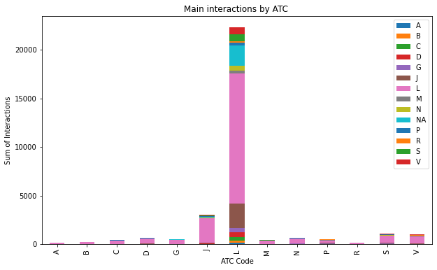

```python
bar_chart(neighbor_analysis(subgraph_com1),['A', 'B', 'C', 'D', 'G', 'J', 'L', 'M', 'N', 'NA', 'P', 'R', 'S', 'V'])
```

# **7.4) Community 2. Alimentary Tract (A) /Cardiovascular (C) /Antiinfective (J) /Nervious(N)**

**Main interactions with Alimentary (A) ,Cardiovascular(C) and Sensory Organs (S)**

```python
neighbor_analysis(subgraph_com2)
```

|  | atc_code1 | count | degree | strength | avg strength | A | B | C | D | G | H | J | L | M | N | NA | P | R | S | V |
| --- | --- | --- | --- | --- | --- | --- | --- | --- | --- | --- | --- | --- | --- | --- | --- | --- | --- | --- | --- | --- |
| 0 | A | 71 | 342.154930 | 690.830986 | 2.066171 | 2324 | 725 | 2331 | 1778 | 963 | 482 | 1989 | 600 | 1160 | 1902 | 100 | 124 | 1338 | 2189 | 435 |
| 1 | B | 23 | 285.217391 | 579.478261 | 1.988920 | 725 | 246 | 735 | 540 | 265 | 163 | 569 | 168 | 315 | 582 | 9 | 38 | 420 | 672 | 149 |
| 2 | C | 67 | 264.611940 | 533.686567 | 2.017469 | 2331 | 735 | 1190 | 1815 | 654 | 574 | 907 | 652 | 528 | 689 | 27 | 98 | 1474 | 1683 | 397 |
| 3 | D | 64 | 299.609375 | 609.843750 | 2.017467 | 1778 | 540 | 1815 | 1424 | 783 | 363 | 1408 | 452 | 986 | 1470 | 57 | 101 | 1088 | 1632 | 258 |
| 4 | G | 30 | 218.433333 | 435.366667 | 2.006716 | 963 | 265 | 654 | 783 | 286 | 215 | 485 | 239 | 299 | 427 | 14 | 38 | 588 | 790 | 109 |
| 5 | H | 14 | 456.285714 | 930.785714 | 2.108410 | 482 | 163 | 574 | 363 | 215 | 104 | 333 | 132 | 254 | 433 | 13 | 30 | 298 | 407 | 81 |
| 6 | J | 94 | 116.138298 | 238.574468 | 2.055933 | 1989 | 569 | 907 | 1408 | 485 | 333 | 1364 | 461 | 640 | 563 | 106 | 102 | 958 | 1757 | 268 |
| 7 | L | 23 | 285.086957 | 597.391304 | 2.013648 | 600 | 168 | 652 | 452 | 239 | 132 | 461 | 152 | 254 | 458 | 32 | 29 | 314 | 546 | 97 |
| 8 | M | 32 | 211.250000 | 435.093750 | 2.055223 | 1160 | 315 | 528 | 986 | 299 | 254 | 640 | 254 | 178 | 296 | 63 | 40 | 667 | 1073 | 164 |
| 9 | N | 57 | 180.631579 | 371.666667 | 2.063640 | 1902 | 582 | 689 | 1470 | 427 | 433 | 563 | 458 | 296 | 290 | 8 | 86 | 1176 | 1314 | 225 |
| 10 | P | 5 | 201.400000 | 368.400000 | 1.953503 | 124 | 38 | 98 | 101 | 38 | 30 | 102 | 29 | 40 | 86 | 1 | 6 | 70 | 122 | 17 |
| 11 | R | 41 | 352.243902 | 713.317073 | 1.975477 | 1338 | 420 | 1474 | 1088 | 588 | 298 | 958 | 314 | 667 | 1176 | 22 | 70 | 910 | 1281 | 193 |
| 12 | S | 75 | 269.026667 | 552.746667 | 2.046070 | 2189 | 672 | 1683 | 1632 | 790 | 407 | 1757 | 546 | 1073 | 1314 | 103 | 122 | 1281 | 2026 | 373 |
| 13 | V | 20 | 142.750000 | 309.900000 | 2.176084 | 435 | 149 | 397 | 258 | 109 | 81 | 268 | 97 | 164 | 225 | 32 | 17 | 193 | 373 | 100 |

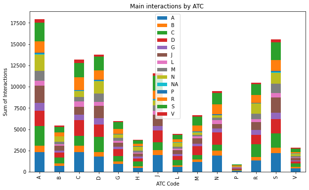

```python
bar_chart(neighbor_analysis(subgraph_com2),['A', 'B', 'C', 'D', 'G', 'J', 'L', 'M', 'N', 'NA', 'P', 'R', 'S', 'V'])
```

# **7.5) Community 3. Alimentary Tract (A) /DRUGS USED IN DIABETES A10**

```python
neighbor_analysis(subgraph_com3)
```

|  | atc_code1 | count | degree | strength | avg strength | A | B | C | D | G | H | J | L | M | N | NA | P | R | S | V |
| --- | --- | --- | --- | --- | --- | --- | --- | --- | --- | --- | --- | --- | --- | --- | --- | --- | --- | --- | --- | --- |
| 0 | A | 128 | 215.109375 | 416.984375 | 1.921278 | 4010 | 477 | 3397 | 2279 | 1597 | 1336 | 1375 | 497 | 45 | 564 | 525 | 71 | 1469 | 2733 | 448 |
| 1 | B | 36 | 44.222222 | 86.472222 | 1.938310 | 477 | 56 | 137 | 51 | 56 | 28 | 138 | 10 | 13 | 24 | 18 | 4 | 69 | 111 | 52 |
| 2 | C | 76 | 120.750000 | 240.486842 | 1.955120 | 3397 | 137 | 270 | 257 | 50 | 276 | 45 | 67 | 0 | 145 | 76 | 6 | 397 | 413 | 300 |
| 3 | D | 78 | 56.076923 | 99.564103 | 1.728661 | 2279 | 51 | 257 | 196 | 112 | 33 | 130 | 111 | 8 | 113 | 66 | 6 | 53 | 202 | 79 |
| 4 | G | 32 | 101.968750 | 205.656250 | 1.996960 | 1597 | 56 | 50 | 112 | 8 | 121 | 47 | 11 | 0 | 7 | 22 | 8 | 87 | 105 | 39 |
| 5 | H | 26 | 125.115385 | 248.461538 | 1.818451 | 1336 | 28 | 276 | 33 | 121 | 2 | 37 | 26 | 2 | 15 | 37 | 1 | 29 | 88 | 52 |
| 6 | J | 32 | 120.781250 | 248.531250 | 2.043102 | 1375 | 138 | 45 | 130 | 47 | 37 | 4 | 101 | 0 | 19 | 37 | 0 | 36 | 85 | 92 |
| 7 | L | 16 | 102.312500 | 210.437500 | 2.087495 | 497 | 10 | 67 | 111 | 11 | 26 | 101 | 48 | 0 | 8 | 15 | 1 | 18 | 86 | 13 |
| 8 | M | 5 | 26.600000 | 57.600000 | 2.205704 | 45 | 13 | 0 | 8 | 0 | 2 | 0 | 0 | 0 | 1 | 2 | 0 | 0 | 0 | 11 |
| 9 | N | 24 | 75.000000 | 160.791667 | 2.098772 | 564 | 24 | 145 | 113 | 7 | 15 | 19 | 8 | 1 | 128 | 27 | 9 | 94 | 146 | 23 |
| 10 | P | 6 | 23.166667 | 41.333333 | 1.992163 | 71 | 4 | 6 | 6 | 8 | 1 | 0 | 1 | 0 | 9 | 4 | 0 | 3 | 9 | 4 |
| 11 | R | 41 | 105.829268 | 211.609756 | 1.840557 | 1469 | 69 | 397 | 53 | 87 | 29 | 36 | 18 | 0 | 94 | 86 | 3 | 154 | 204 | 43 |
| 12 | S | 66 | 125.151515 | 249.954545 | 1.880539 | 2733 | 111 | 413 | 202 | 105 | 88 | 85 | 86 | 0 | 146 | 86 | 9 | 204 | 322 | 158 |
| 13 | V | 36 | 48.722222 | 97.833333 | 2.064523 | 448 | 52 | 300 | 79 | 39 | 52 | 92 | 13 | 11 | 23 | 59 | 4 | 43 | 158 | 58 |

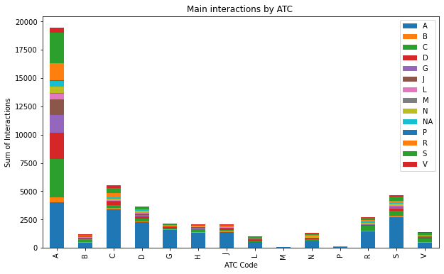

```python
bar_chart(neighbor_analysis(subgraph_com3),['A', 'B', 'C', 'D', 'G', 'J', 'L', 'M', 'N', 'NA', 'P', 'R', 'S', 'V'])
```

# **7.6) Community 4. Antineoplastics (L)**

**Main Interactions:Severe interactions mainly with Nervous system (N) and antiinfective drugs (J)**

```python
neighbor_analysis(subgraph_com4)
```

|  | atc_code1 | count | degree | strength | avg strength | A | B | C | D | G | H | J | L | M | N | NA | P | R | S | V |
| --- | --- | --- | --- | --- | --- | --- | --- | --- | --- | --- | --- | --- | --- | --- | --- | --- | --- | --- | --- | --- |
| 0 | A | 49 | 181.510204 | 384.000000 | 2.073998 | 336 | 79 | 346 | 169 | 235 | 175 | 787 | 1520 | 19 | 718 | 49 | 148 | 257 | 98 | 57 |
| 1 | B | 11 | 156.272727 | 331.545455 | 2.173993 | 79 | 10 | 68 | 35 | 53 | 34 | 164 | 328 | 3 | 137 | 8 | 34 | 52 | 17 | 13 |
| 2 | C | 31 | 150.838710 | 340.193548 | 2.212033 | 346 | 68 | 62 | 135 | 108 | 122 | 222 | 1184 | 13 | 92 | 31 | 135 | 315 | 84 | 42 |
| 3 | D | 28 | 147.178571 | 309.071429 | 1.997083 | 169 | 35 | 135 | 114 | 137 | 73 | 527 | 548 | 9 | 240 | 19 | 38 | 123 | 73 | 36 |
| 4 | G | 26 | 157.423077 | 336.230769 | 2.125530 | 235 | 53 | 108 | 137 | 108 | 110 | 271 | 847 | 10 | 165 | 22 | 76 | 235 | 101 | 31 |
| 5 | H | 14 | 236.214286 | 513.285714 | 2.124032 | 175 | 34 | 122 | 73 | 110 | 58 | 300 | 600 | 11 | 258 | 23 | 69 | 141 | 37 | 30 |
| 6 | J | 65 | 181.323077 | 404.292308 | 2.198977 | 787 | 164 | 222 | 527 | 271 | 300 | 354 | 2593 | 32 | 259 | 58 | 328 | 696 | 281 | 107 |
| 7 | L | 89 | 340.157303 | 774.696629 | 2.261632 | 1520 | 328 | 1184 | 548 | 847 | 600 | 2593 | 4560 | 123 | 2333 | 244 | 512 | 1297 | 273 | 231 |
| 8 | M | 3 | 255.333333 | 537.000000 | 2.086201 | 19 | 3 | 13 | 9 | 10 | 11 | 32 | 123 | 2 | 38 | 3 | 16 | 21 | 5 | 5 |
| 9 | N | 57 | 168.508772 | 367.052632 | 2.138539 | 718 | 137 | 92 | 240 | 165 | 258 | 259 | 2333 | 38 | 68 | 77 | 307 | 660 | 165 | 75 |
| 10 | P | 15 | 211.333333 | 479.600000 | 2.194439 | 148 | 34 | 135 | 38 | 76 | 69 | 328 | 512 | 16 | 307 | 37 | 50 | 150 | 26 | 29 |
| 11 | R | 58 | 146.293103 | 306.155172 | 2.098720 | 257 | 52 | 315 | 123 | 235 | 141 | 696 | 1297 | 21 | 660 | 57 | 150 | 1100 | 268 | 67 |
| 12 | S | 26 | 100.500000 | 211.115385 | 2.081765 | 98 | 17 | 84 | 73 | 101 | 37 | 281 | 273 | 5 | 165 | 9 | 26 | 268 | 52 | 22 |
| 13 | V | 7 | 167.571429 | 394.428571 | 2.192687 | 57 | 13 | 42 | 36 | 31 | 30 | 107 | 231 | 5 | 75 | 7 | 29 | 67 | 22 | 6 |

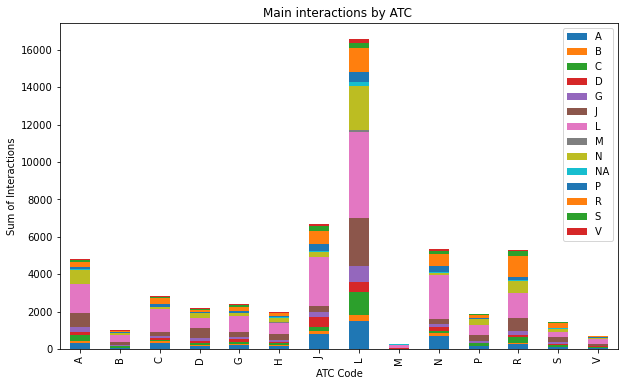

```python
bar_chart(neighbor_analysis(subgraph_com4),['A', 'B', 'C', 'D', 'G', 'J', 'L', 'M', 'N', 'NA', 'P', 'R', 'S', 'V'])
```

# **7.7) Community 5. Nervious System (N)**

**Main Interactions:Nervious System (N) mainly interactions with respitatory drugs(R)**

```python
neighbor_analysis(subgraph_com5)
```

|  | atc_code1 | count | degree | strength | avg strength | A | B | C | D | G | H | J | L | M | N | NA | P | R | S | V |
| --- | --- | --- | --- | --- | --- | --- | --- | --- | --- | --- | --- | --- | --- | --- | --- | --- | --- | --- | --- | --- |
| 0 | A | 27 | 173.185185 | 355.148148 | 2.100505 | 150 | 14 | 85 | 173 | 71 | 0 | 11 | 12 | 39 | 1217 | 62 | 3 | 551 | 171 | 92 |
| 1 | B | 4 | 78.750000 | 135.750000 | 1.568817 | 14 | 0 | 6 | 15 | 4 | 0 | 0 | 1 | 2 | 77 | 6 | 0 | 58 | 12 | 8 |
| 2 | C | 19 | 61.842105 | 123.263158 | 2.013847 | 85 | 6 | 8 | 109 | 6 | 0 | 0 | 21 | 4 | 166 | 19 | 0 | 219 | 72 | 33 |
| 3 | D | 21 | 235.428571 | 479.619048 | 2.169101 | 173 | 15 | 109 | 156 | 69 | 0 | 8 | 31 | 65 | 1349 | 60 | 2 | 535 | 164 | 103 |
| 4 | G | 15 | 58.200000 | 117.200000 | 2.100036 | 71 | 4 | 6 | 69 | 8 | 0 | 0 | 8 | 2 | 93 | 18 | 2 | 211 | 44 | 23 |
| 5 | H | 2 | 2.000000 | 4.000000 | 2.000000 | 0 | 0 | 0 | 0 | 0 | 0 | 0 | 0 | 0 | 0 | 0 | 0 | 0 | 0 | 4 |
| 6 | J | 5 | 39.400000 | 84.800000 | 2.237348 | 11 | 0 | 0 | 8 | 0 | 0 | 0 | 2 | 0 | 14 | 2 | 3 | 32 | 6 | 11 |
| 7 | L | 6 | 297.500000 | 651.000000 | 2.460536 | 12 | 1 | 21 | 31 | 8 | 0 | 2 | 8 | 10 | 288 | 9 | 0 | 103 | 22 | 17 |
| 8 | M | 8 | 60.375000 | 123.875000 | 2.070519 | 39 | 2 | 4 | 65 | 2 | 0 | 0 | 10 | 0 | 19 | 11 | 0 | 170 | 34 | 20 |
| 9 | N | 135 | 137.318519 | 288.637037 | 2.093345 | 1217 | 77 | 166 | 1349 | 93 | 0 | 14 | 288 | 19 | 888 | 234 | 67 | 3734 | 994 | 712 |
| 10 | P | 6 | 39.833333 | 81.500000 | 2.216495 | 3 | 0 | 0 | 2 | 2 | 0 | 3 | 0 | 0 | 67 | 2 | 4 | 10 | 2 | 15 |
| 11 | R | 59 | 198.084746 | 403.983051 | 2.023533 | 551 | 58 | 219 | 535 | 211 | 0 | 32 | 103 | 170 | 3734 | 176 | 10 | 1618 | 520 | 268 |
| 12 | S | 29 | 120.448276 | 240.551724 | 2.055632 | 171 | 12 | 72 | 164 | 44 | 0 | 6 | 22 | 34 | 994 | 46 | 2 | 520 | 132 | 80 |
| 13 | V | 23 | 132.565217 | 288.869565 | 2.055982 | 92 | 8 | 33 | 103 | 23 | 4 | 11 | 17 | 20 | 712 | 22 | 15 | 268 | 80 | 36 |

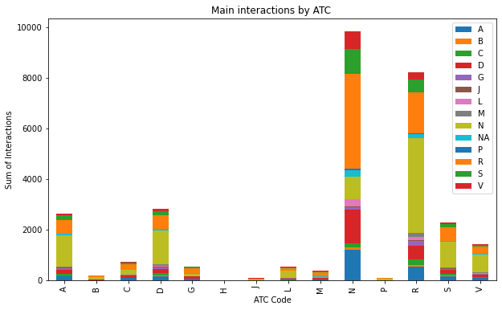

```python
bar_chart(neighbor_analysis(subgraph_com5),['A', 'B', 'C', 'D', 'G', 'J', 'L', 'M', 'N', 'NA', 'P', 'R', 'S', 'V'])
```

# **7.8) Community 6. Blood (B)**

**Mainly interactions with Musculo skeletal systems(M)**

```python
neighbor_analysis(subgraph_com6)
```

|  | atc_code1 | count | degree | strength | avg strength | A | B | C | D | G | H | J | L | M | N | NA | P | R | S | V |
| --- | --- | --- | --- | --- | --- | --- | --- | --- | --- | --- | --- | --- | --- | --- | --- | --- | --- | --- | --- | --- |
| 0 | A | 8 | 98.125000 | 206.375000 | 2.118771 | 6 | 95 | 5 | 0 | 0 | 3 | 0 | 18 | 82 | 29 | 1 | 0 | 4 | 21 | 7 |
| 1 | B | 47 | 160.872340 | 370.276596 | 2.340684 | 95 | 1460 | 136 | 113 | 67 | 72 | 36 | 357 | 1009 | 548 | 174 | 0 | 76 | 377 | 203 |
| 2 | C | 5 | 86.800000 | 191.800000 | 2.083274 | 5 | 136 | 0 | 4 | 0 | 5 | 0 | 20 | 13 | 2 | 4 | 0 | 5 | 12 | 10 |
| 3 | D | 8 | 32.250000 | 60.625000 | 1.977790 | 0 | 113 | 4 | 0 | 0 | 2 | 0 | 19 | 46 | 4 | 0 | 0 | 2 | 16 | 7 |
| 4 | G | 7 | 22.714286 | 46.000000 | 2.423810 | 0 | 67 | 0 | 0 | 0 | 2 | 0 | 8 | 0 | 0 | 1 | 0 | 0 | 2 | 4 |
| 5 | H | 4 | 61.750000 | 135.750000 | 2.036460 | 3 | 72 | 5 | 2 | 2 | 0 | 1 | 10 | 50 | 16 | 9 | 0 | 4 | 17 | 6 |
| 6 | J | 2 | 97.000000 | 227.500000 | 2.667539 | 0 | 36 | 0 | 0 | 0 | 1 | 0 | 7 | 0 | 0 | 0 | 0 | 0 | 1 | 3 |
| 7 | L | 11 | 178.181818 | 441.090909 | 2.335601 | 18 | 357 | 20 | 19 | 8 | 10 | 7 | 52 | 169 | 77 | 27 | 0 | 16 | 68 | 28 |
| 8 | M | 31 | 172.612903 | 372.258065 | 2.107908 | 82 | 1009 | 13 | 46 | 0 | 50 | 0 | 169 | 182 | 51 | 4 | 0 | 46 | 126 | 105 |
| 9 | N | 16 | 192.250000 | 411.312500 | 2.095740 | 29 | 548 | 2 | 4 | 0 | 16 | 0 | 77 | 51 | 26 | 9 | 1 | 14 | 38 | 41 |
| 10 | P | 1 | 6.000000 | 13.000000 | 2.166667 | 0 | 0 | 0 | 0 | 0 | 0 | 0 | 0 | 0 | 1 | 0 | 0 | 0 | 0 | 0 |
| 11 | R | 3 | 155.000000 | 333.333333 | 2.185920 | 4 | 76 | 5 | 2 | 0 | 4 | 0 | 16 | 46 | 14 | 2 | 0 | 2 | 17 | 7 |
| 12 | S | 14 | 128.785714 | 281.071429 | 2.255825 | 21 | 377 | 12 | 16 | 2 | 17 | 1 | 68 | 126 | 38 | 12 | 0 | 17 | 60 | 38 |
| 13 | V | 7 | 156.428571 | 372.428571 | 2.315155 | 7 | 203 | 10 | 7 | 4 | 6 | 3 | 28 | 105 | 41 | 8 | 0 | 7 | 38 | 10 |

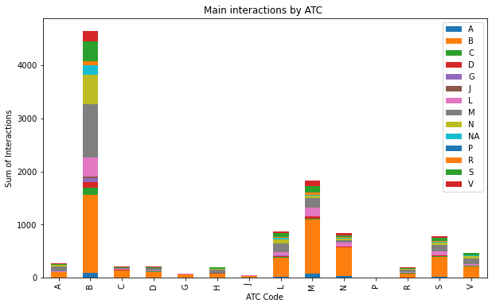

```python
bar_chart(neighbor_analysis(subgraph_com6),['A', 'B', 'C', 'D', 'G', 'J', 'L', 'M', 'N', 'NA', 'P', 'R', 'S', 'V'])
```